# Reproducible Research: Peer Assessment 1

Author: Jeet Bhadouria

This project analyzes data from a personal activity monitor that recorded the number of steps taken at 5-minute intervals over two months (October–November 2012). The goal is to explore activity patterns using reproducible data analysis.

The data set includes:

Steps: Number of steps in each 5-minute interval

Date: The date of recording

Interval: Identifier for each 5-minute time slot

## Loading and preprocessing the data

```r
data<- read.csv("~/Documents/activity.csv", colClasses = c("numeric", "Date", "numeric"))
# having a glimpse of structure of our loaded data
summary(data)
```

```
##      steps             date               interval
##  Min.   :  0.00   Min.   :2012-10-01   Min.   :   0.0
##  1st Qu.:  0.00   1st Qu.:2012-10-16   1st Qu.: 588.8
##  Median :  0.00   Median :2012-10-31   Median :1177.5
##  Mean   : 37.38   Mean   :2012-10-31   Mean   :1177.5
##  3rd Qu.: 12.00   3rd Qu.:2012-11-15   3rd Qu.:1766.2
##  Max.   :806.00   Max.   :2012-11-30   Max.   :2355.0
##  NA's   :2304
```

Removing NA

```r
set<- data[!is.na(data),]
```

# Question 1:

For this part we have to calculate the total number of steps taken each day.

```r
set1<- aggregate(steps~date,set, sum)
```

For the second part we have to make a histogram on the previous aggregated data we got.

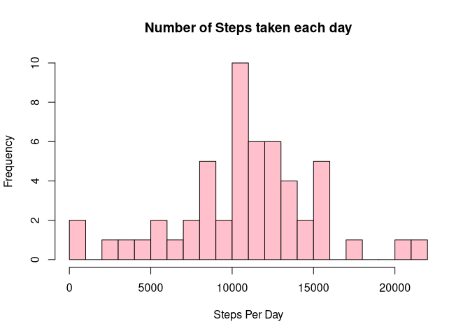

```r
hist(set1$steps,breaks = 20, xlab = "Steps Per Day",
     main = "Number of Steps taken each day", col = "pink")
```

```r
library(dplyr)
sort_set<-set1%>%
  summarise(mean = mean(steps), median = median(steps))
```

## What is the average daily activity pattern?

# Question 2:

In the first part we need to make a time series plot;

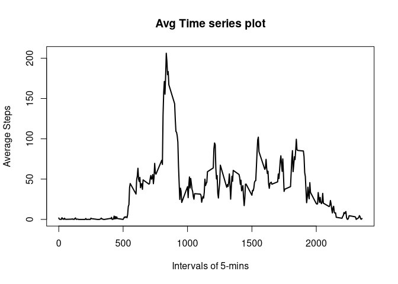

```r
stepint<- aggregate(steps~interval, data, mean)
plot(stepint$interval, stepint$steps,
     type = "l", lwd = 2,
     main = "Avg Time series plot",
     xlab = "Intervals of 5-mins",
     ylab = "Average Steps")
```

For the second part we need to return the maximum value and the point of interval from data

```r
stepint[grep(max(stepint$steps), stepint$steps),]
```

```
##     interval    steps
## 104      835 206.1698
```

# Question 3:

For this part we need to calculate the total number of NA values in each row

```r
library(dplyr)
data%>%
  summarise(total_number_of_NA = sum(is.na(data)))
```

```
##   total_number_of_NA
## 1               2304
```

For the second part we need to impute the average step counts in place of NAs

```r
set2<- data
for (i in 1:nrow(set2)) {
  if(is.na(data[i,1])==TRUE){
    set2[i,1]<- stepint[stepint$interval %in% set2[i,3], 2]
  }
}
```

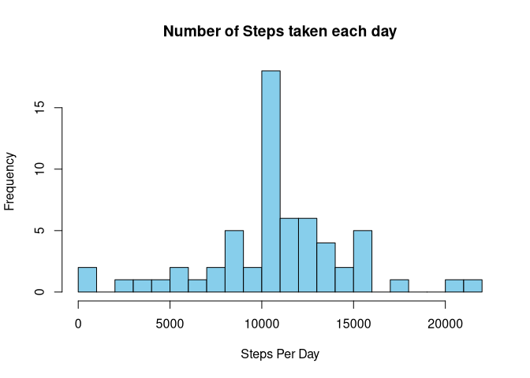

```r
set3<- aggregate(steps~date, set2, sum)
hist(set3$steps, breaks = 20, xlab = "Steps Per Day",
     main = "Number of Steps taken each day", col = "skyblue")
```

Process:

```r
sort_set2<- set3%>%
  summarise(Avgsteps = mean(steps), centralsteps = median(steps))
```

At last we are asked to compare the first data of first question and the third question through histogram:

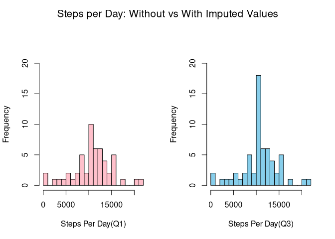

```r
par(mfrow = c(1, 2), oma = c(0, 0, 2, 0))
#from 1st data:
hist(set1$steps,breaks = 20, xlab = "Steps Per Day(Q1)",ylim = c(0,20),
     col = "pink", main = NULL)
#from question 3rd data:
hist(set3$steps, breaks = 20, xlab = "Steps Per Day(Q3)",ylim = c(0,20),
    col = "skyblue",main = NULL)
#Giving title to histogram
mtext("Steps per Day: Without vs With Imputed Values", outer = TRUE, cex = 1.3)
```

Conclusion: By analyzing our comparative plot we get as an output we can see how imputing the NA values with the values have changed the number of frequencies as it created much our data much dense comparatively just ignoring the NAs.

## Are there differences in activity patterns between weekdays and weekends?

# Question 4:

We are asked to make new variable to store whether the date is weekday or weekend day

```r
set4<-data
# getting the days name and storing it in to new variable
set4$days<- weekdays(set4$date)
# creating a new variable of character class
set4$level<- as.character(rep(0, times = nrow(set4)))
#creating a loop to get weekdays and weekends and storing it to the empty variable weve created in the previous step
for(i in 1:nrow(set4)){
  if(set4[i,4] %in% c("Saturday", "Sunday")){
    set4[i,5]<- "Weekend"
  }else{
    set4[i,5]<- "Weekday"
  }
}
# preview of the data
set4$level<- as.factor(set4$level)
table(set4$level)
```

```
##
## Weekday Weekend
##   12960    4608
```

For this part we are asked to make a time series plot of average steps per 5-min interval, seperately for weekdays and weekends

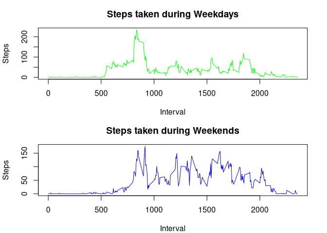

```r
# Taking out weekdays and weekends to plot them seperatly
weekday<- set4[set4$level == "Weekday",]
weekend<- set4[set4$level == "Weekend",]
# taking the average of average by taking interval as independent variable
avg_weekday<- aggregate(steps~interval, weekday, mean)
avg_weekend<- aggregate(steps~interval, weekend, mean)
#creating a time series plot
par(mfrow=c(2,1),mar=c(4,4.1,3,2.1))
plot(avg_weekday$interval, avg_weekday$steps, type = "l", xlab = "Interval", ylab = "Steps", main = "Steps taken during Weekdays", col = "green")
plot(avg_weekend$interval, avg_weekend$steps, type = "l", xlab = "Interval", ylab = "Steps", main = "Steps taken during Weekends", col = "blue")
```

Now that all the questions and tasks are done, we can finally wrap up our project.

THANK YOU!!!